# Spatial data, macroecological patterns and SDMs using R

Plot using `tidyterra`’s `geom_spatraster()`:

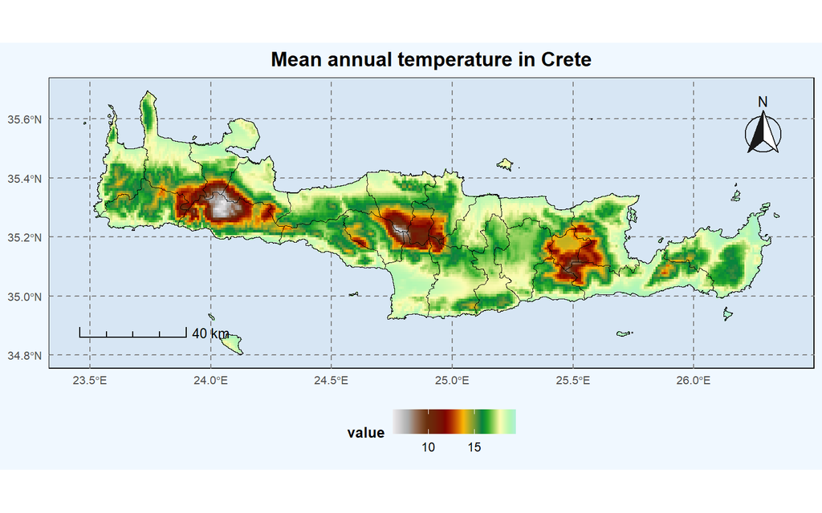

```r
ggplot() +
  geom_spatvector(
  data = Crete,
  # fill = color_land,
  color = 'black',
  linewidth = 0.3
) +
  geom_spatraster(data = current_climate,
                  aes(fill = bio_1)) +
  scale_fill_hypso_c(direction = -1,
                     palette = 'wiki-schwarzwald-cont') +
  ggtitle("Mean annual temperature in Crete") +

  annotation_north_arrow(
  location = "tr", # Top-Right (keeps it clear of Crete's long horizontal shape)
  which_north = "true",
  pad_x = unit(0.2, "in"),
  pad_y = unit(0.2, "in"),
  style = north_arrow_fancy_orienteering(
    fill = c("grey10", "white"),
    line_col = "grey10"
  )
) +

  annotation_scale(
    location = "bl", # Bottom-Left
    width_hint = 0.15,
    style = "ticks",
    text_cex = 0.8,
    pad_x = unit(0.3, "in"),
    pad_y = unit(0.3, "in")
  ) +
  geom_spatvector(
  data = Crete,
  fill = NA,
  color = 'black',
  linewidth = 0.3
) +
  theme_minimal() +
  theme(

  # Basic Plot Titles
  plot.title = element_text(face = "bold", size = 14, hjust = 0.5),
  axis.title = element_blank(), # Standard for map frames

  # Gridlines (Graticules) - Make them light, dashed white
  panel.grid = element_line(color = "white",
                            linetype = "dashed",
                            linewidth = 0.2),

  # Legend Placement - Moving to the right looks cleaner when combined with scale elements
  legend.position = "bottom",
  legend.title = element_text(size = 10, face = "bold"),
  legend.text = element_text(size = 9),
  legend.direction = "horizontal",

  # Color the Sea
  # panel.background = element_rect(fill = color_sea, color = NA),
  plot.background = element_rect(fill = color_sea, color = NA),

  # Axis Text (Lat/Lon labels)
  axis.text = element_text(size = 8, color = "grey30"),

  panel.grid.major = element_line(color = gray(0.5),
                                  linetype = "dashed",
                                  size = 0.5),

  panel.background = element_rect(fill = col2alpha('steelblue', 0.15)))
```

## 3.1 **Calculate some statistics**

`terra` provides `global()` (the modern equivalent of `cellStats()`) plus `summary()`, `hist()`, `boxplot()`, `density()`, and `pairs()` for `SpatRaster` objects.

```r
##============================================================================##
## Summary statistics (mean, min, max, etc.)
##============================================================================##
global(current_climate, fun = "mean", na.rm = TRUE)
global(current_climate, fun = "sd",   na.rm = TRUE)
summary(current_climate)
```

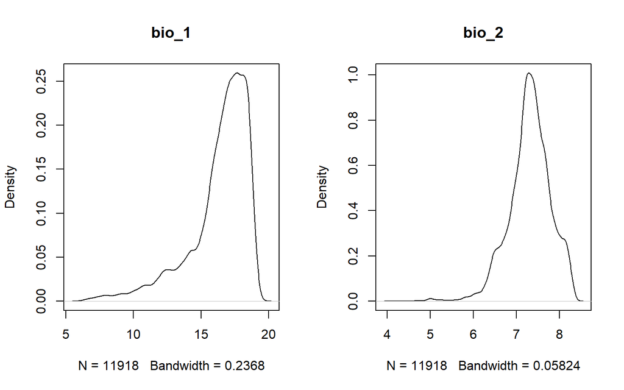

```r
##============================================================================##
## Density / boxplot / correlation plots
##============================================================================##
density(current_climate[[1:2]])
```

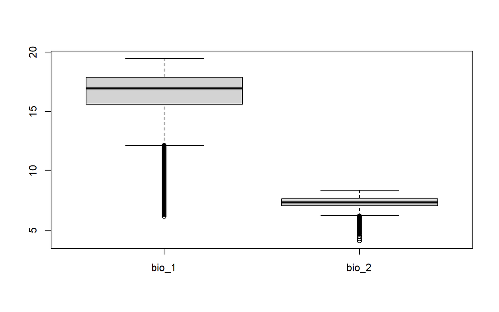

```r
boxplot(current_climate[[1:2]])
```

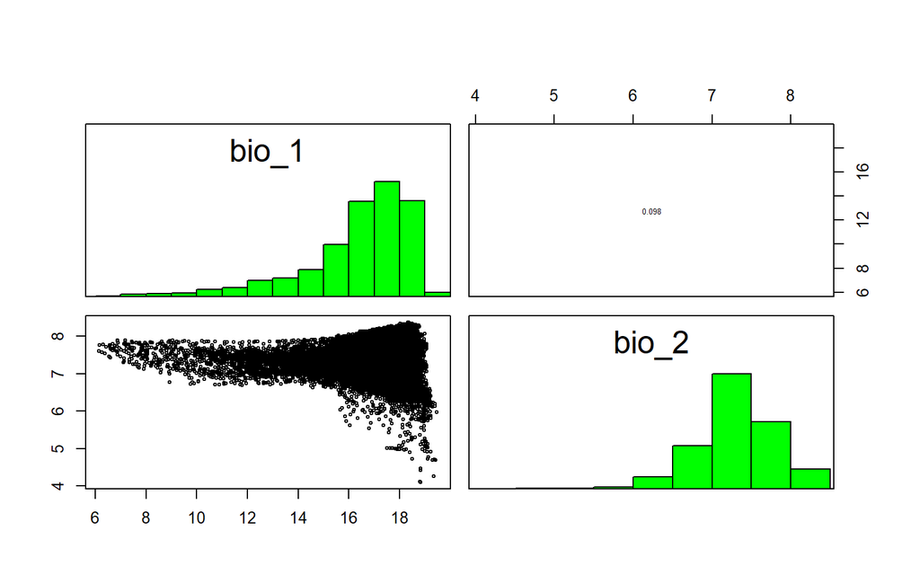

```r
pairs(current_climate[[1:2]])
```

## 3.2 **Correlation among raster data**

To avoid multicollinearity in our downstream models (e.g., SDMs), we should not retain highly correlated predictors. The classic threshold is $r > 0.7$ and for Variance Inflation Factors is 2.5[^5]. We will use the `collinear` R package to do this:

```r
uncorrelated_vars <- collinear(current_climate %>%
                                 as.data.frame(),
                               max_cor = 0.7,
                               max_vif = 2.5)$result$df %>%
  as_tibble()

uncorrelated_vars %>% head()
```

| aspect | hli | tpi | population | bio_2 | clay | footprint | slope | bio_15 | bio_18 |
| --- | --- | --- | --- | --- | --- | --- | --- | --- | --- |
| NA | NA | NA | 5.7 | NA | 48.48892 | 2 | NA | NA | NA |
| 3.2245123 | 0.7509630 | 4.754420 | 5.7 | 5.858333 | 131.89265 | 3 | 0.3257546 | 86.48098 | 7 |
| 0.8969305 | 0.5764681 | -2.506104 | 5.7 | 5.875000 | 64.75261 | 4 | 0.2990154 | 87.75986 | 5 |
| NA | NA | NA | 5.7 | NA | 15.02221 | 4 | NA | NA | NA |
| NA | NA | NA | 5.7 | NA | 51.81186 | 1 | NA | NA | NA |
| 4.7424970 | 0.8542075 | 3.262327 | 5.7 | 5.916667 | 146.92366 | 6 | 0.3285107 | 86.87444 | 6 |

## 3.3 **Raster extraction**

The simplest example is extracting the value of a raster cell at specific points. For this purpose, we will use the point data we subsetted earlier, `occs_Sfakia` and `occs_Rethymno`. We will then compare if the species that are both present in these two spatial subsets have significantly different environmental preferences.

```r
##============================================================================##
## Extract climate at the GBIF occurrence points
##============================================================================##
Sfakia_data <- terra::extract(current_climate,
                                occs_Sfakia,
                                method = "bilinear",
                                xy = T)  %>%
  st_as_sf(coords = c("x", "y"), crs = 4326)

Rethymno_data <- terra::extract(current_climate,
                                occs_Rethymno,
                                method = "bilinear",
                                xy = T) %>%
  st_as_sf(coords = c("x", "y"), crs = 4326)

##============================================================================##
## Bind extracted values to the original sf attributes
##============================================================================##
occs_Sfakia_sf <- occs_Sfakia %>%
  st_as_sf()

occs_Rethymno_sf <- occs_Rethymno %>%
  st_as_sf()

Sfakia_data <- bind_cols(
  st_coordinates(occs_Sfakia_sf) %>%
    as_tibble(),
  Sfakia_data,
  st_drop_geometry(occs_Sfakia_sf)
) %>%
  st_as_sf(coords = c("X", "Y"), crs = 4326)

Rethymno_data <- bind_cols(
  st_coordinates(occs_Rethymno_sf) |> as_tibble(),
  Rethymno_data,
  st_drop_geometry(occs_Rethymno_sf)
) %>%
  st_as_sf(coords = c("X", "Y"), crs = 4326)

##============================================================================##
## Per-species mean of bio_1 and bio_12
##============================================================================##
Sfakia_data_mean <- Sfakia_data %>%
  st_drop_geometry() %>%
  group_by(scientificName) %>%
  summarise(bio1_mean  = mean(bio_1,  na.rm = TRUE),
            bio12_mean = mean(bio_12, na.rm = TRUE),
            .groups = "drop")

Rethymno_data_mean <- Rethymno_data %>%
  st_drop_geometry() %>%
  group_by(scientificName) %>%
  summarise(bio1_mean  = mean(bio_1,  na.rm = TRUE),
            bio12_mean = mean(bio_12, na.rm = TRUE),
            .groups = "drop")

##============================================================================##
## Keep ONLY species present in BOTH counties
##============================================================================##
common_sp <- intersect(Sfakia_data_mean$scientificName,
                       Rethymno_data_mean$scientificName)

Sfakia_subset   <- Sfakia_data_mean %>%
  filter(scientificName %in% common_sp)

Rethymno_subset <- Rethymno_data_mean %>%
  filter(scientificName %in% common_sp)

identical(sort(unique(Sfakia_subset$scientificName)),
          sort(unique(Rethymno_subset$scientificName)))

##============================================================================##
## Build a long table and run ANOVA
##============================================================================##
Sfakia_Rethymno <- bind_rows(
  Sfakia_subset %>% mutate(County = "Sfakia"),
  Rethymno_subset %>% mutate(County = "Rethymno")
) %>%
  mutate(County = factor(County))

summary(aov(bio1_mean  ~ County, data = Sfakia_Rethymno))
summary(aov(bio12_mean ~ County, data = Sfakia_Rethymno))
```

[output not shown]

> Did we find any significant differences?

# 4 Macroecological patterns

We can now use the cleaned occurrence data and the raster data to explore macroecological patterns in Crete.

First, let’s create a phylogenetic tree based on a backbone megaphylogeny for the taxa occurring in Crete according to GBIF:

## 4.1 Megatree & phylogenetic tree

```r
##============================================================================##
## Pre-load the megatree ----
##============================================================================##
mega_tree <- megatrees::tree_plant_otl
##============================================================================##

##============================================================================##
## Create the phylogenetic tree ----
##============================================================================##
phy <- get_tree(data_gr_cleaned %>%
                  distinct(Taxon) %>%
                  pull(Taxon),
                taxon    = 'plant',
                scenario = "random_below_basal",
                mc_cores  = 20)

saveRDS(phy, 'RDS/Phylogenetic tree for the Cretan taxa (40000).rds')
##============================================================================##
```

Then, let’s create a dataframe in the appropriate format for the `epm` package that we are going to use:

```r
# For point occurrences, epm expects a standard dataframe with 3 columns: [X, Y, taxon]
epm_df <- data.frame(
  x = st_coordinates(points_sf)[, "X"],
  y = st_coordinates(points_sf)[, "Y"],
  taxon = points_sf$Taxon
)
```

Then, we will create the epm grid:

```r
##============================================================================##
## Create the grid ----
##============================================================================##
# 3. Create the EcoPhyloMapper Grid Object
# We define a 5000m (5km) hexagonal grid
cretan_epm <- createEPMgrid(
  spDat = epm_df,
  resolution = 5000,           # 10,000 meters = 10km grid cells
  cellType = "hexagon",        # Hexagons are great for natural boundaries
  method = "percentOverlap",   # Better than centroid for irregular mountain tops
  percentThreshold = 0.10,     # E.g., range must cover 10% of the cell to count
  retainSmallRanges = TRUE,
  # nThreads = 20              # Speed it up if your computer has multiple cores!
  crs = 2100
)
##============================================================================##
```

Then, let’s add the phylogeny to the epm grid:

```r
cretan_epm <- addPhylo(cretan_epm, phy)
```

Now, let’s ensure that we’ve kept only the taxa with both the phylogenetic and occurrence data:

```r
cretan_epm <- reduceToCommonTaxa(cretan_epm)
```

Now we are able to calculate several biodiversity metrics:

```r
##============================================================================##
## Estimate several metrics -----------
##============================================================================##
pbd_my_epm <- betadiv_phylogenetic(cretan_epm,
                                   radius = 10000,
                                   component = 'turnover')
tbd_my_epm <- betadiv_taxonomic(cretan_epm,
                                radius = 10000,
                                component = 'turnover')

pwe_my_epm <- gridMetrics(cretan_epm,
                          metric = 'phyloWeightedEndemism')
cwe_my_epm <- gridMetrics(cretan_epm,
                          metric = 'correctedWeightedEndemism')
we_my_epm <- gridMetrics(cretan_epm,
                         metric = 'weightedEndemism')

psv_my_epm <- gridMetrics(cretan_epm,
                          metric = 'PSV')
psr_my_epm <- gridMetrics(cretan_epm,
                          metric = 'PSR')
pd_my_epm <- gridMetrics(cretan_epm,
                         metric = 'pd')
##============================================================================##
```

Then, we will create a single shapefile with all the metrics, which we can then plot:

```r
##============================================================================##
## Create a single shapefile with all the metrics -----------
##============================================================================##
mt_grid <- cretan_epm$grid %>%
  dplyr::mutate(WE = we_my_epm$grid$weightedEndemism,
                CWE = cwe_my_epm$grid$correctedWeightedEndemism,
                PE = pwe_my_epm$grid$phyloWeightedEndemism,
                SR = pwe_my_epm$grid$spRichness,
                PSV = psv_my_epm$grid$PSV,
                PSR = psr_my_epm$grid$PSR,
                PD = pd_my_epm$grid$pd,
                PBD = pbd_my_epm$phylogenetic_turnover,
                TBD = tbd_my_epm$taxonomic_turnover) %>%
  dplyr::select(-spRichness)
##============================================================================##
```

Now let’s plot these metrics to explore the macroecological patterns in Crete. We will use `ggplot2` for this, and we can create a function to plot each metric with a consistent style.

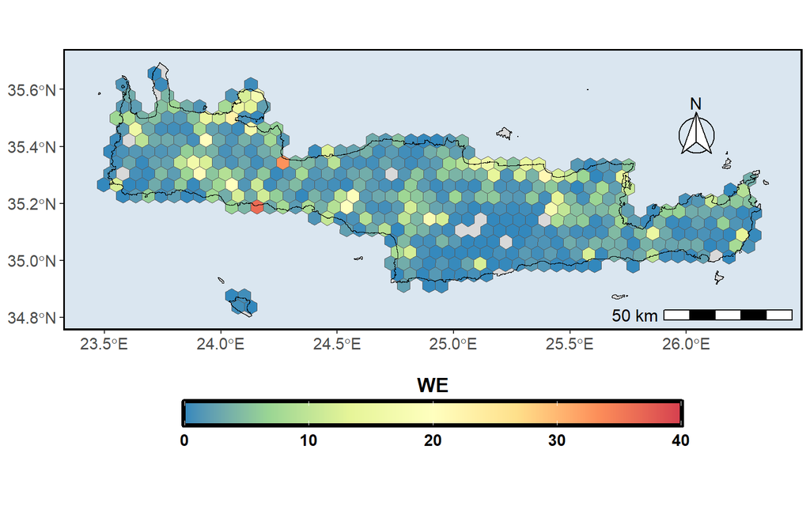

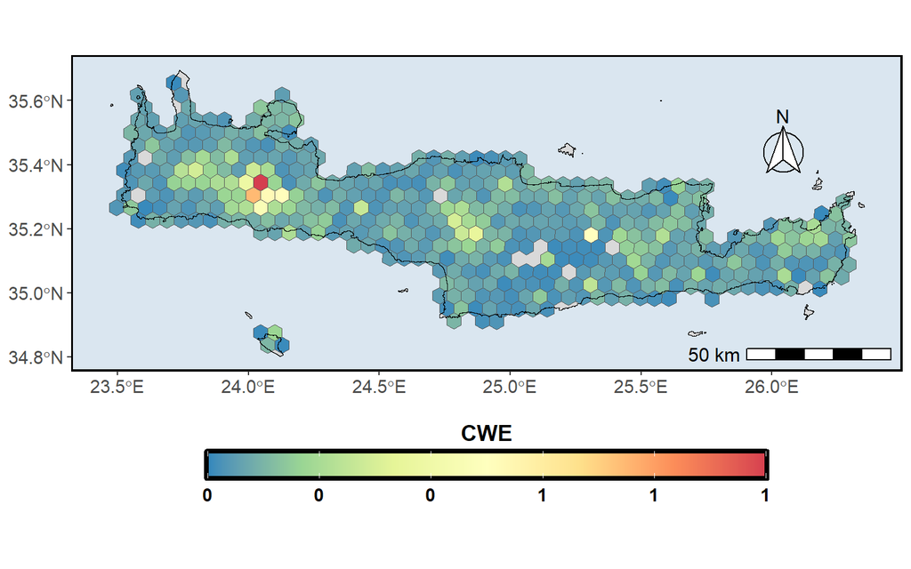

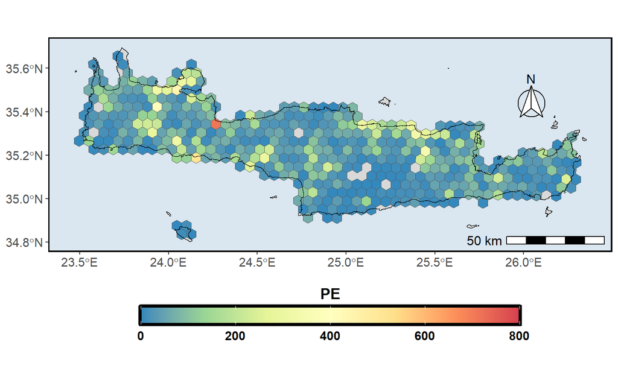

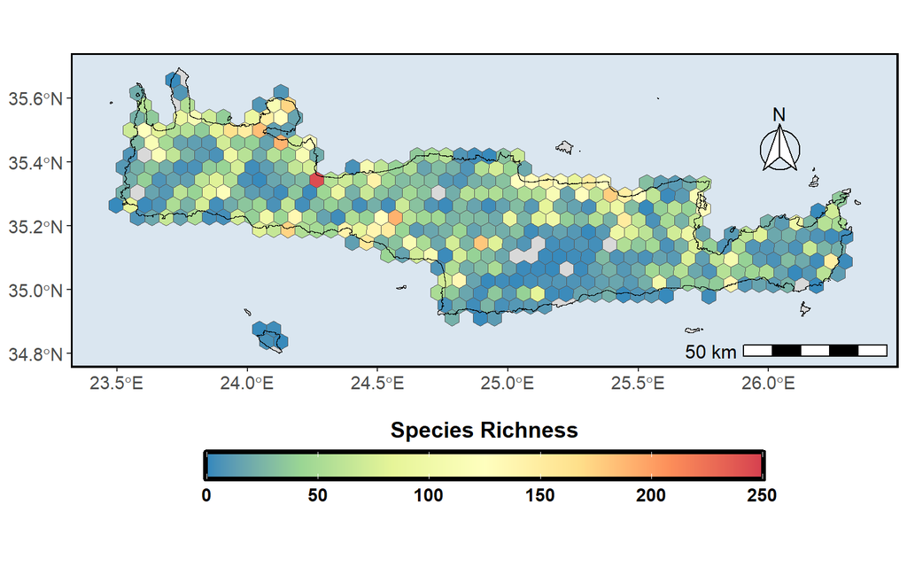

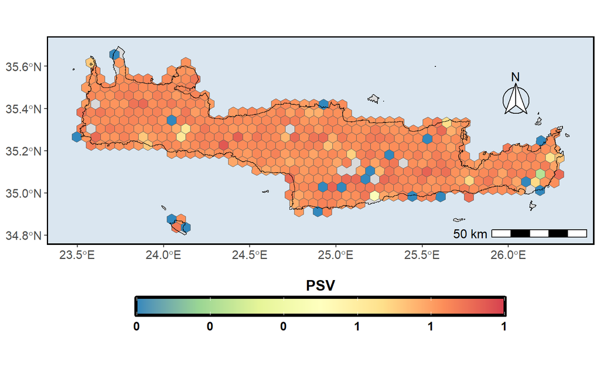

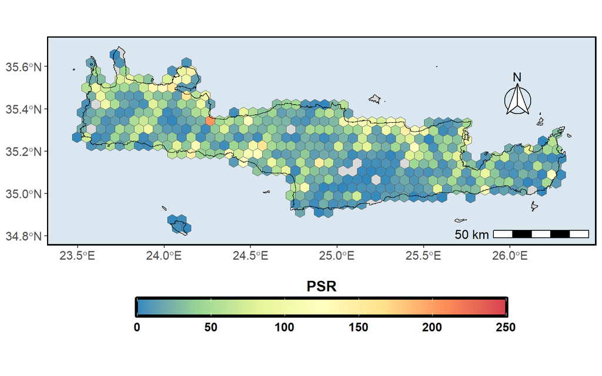

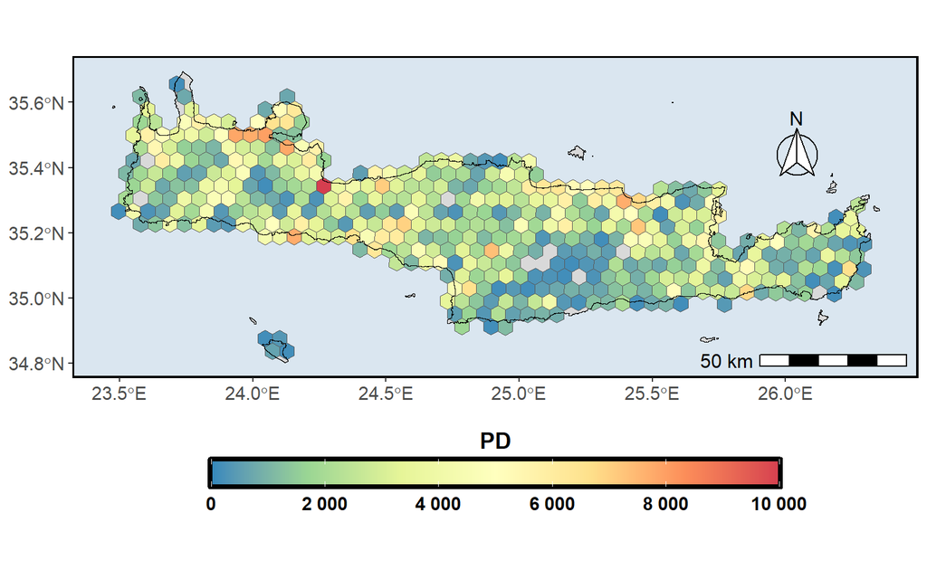

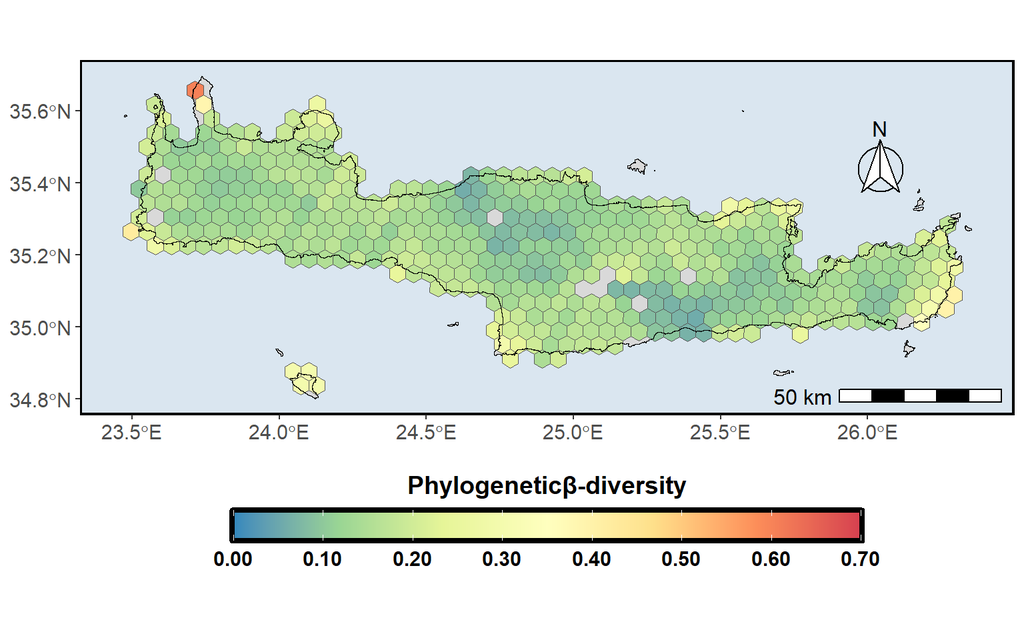

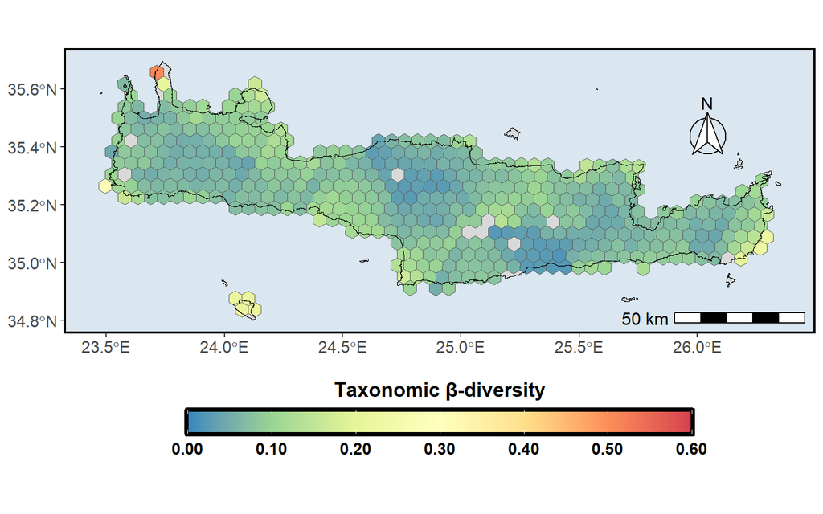

```r
##============================================================================##
## 5. Plot Metrics ----
##============================================================================##

# Define columns to plot and loop through them
# plot_metrics <- c("SR", "TBD", "PBD", "CWE", "WE", "PE", "PSV", "PSR", "PD")

# Optional: set layout to view multiple plots at once, e.g., par(mfrow = c(3, 3))
# for (metric in plot_metrics) {
#   plot(mt_grid[metric], main = metric)
# }

metric_titles <- c(
  WE  = "WE",
  CWE = "CWE",
  PE  = "PE",
  SR  = "Species Richness",
  PSV = "PSV",
  PSR = "PSR",
  PD  = "PD",
  PBD = "Phylogenetic\u03B2-diversity",
  TBD = "Taxonomic \u03B2-diversity"
)

mapRange1 <- c(range(st_coordinates(mt_grid)[, 1]),
               range(st_coordinates(mt_grid)[, 2]))
Crete_agg <- aggregate(Crete)

# Let's create a function to plot each metric with a consistent style, so we can
# easily compare them:
plot_metric <- function(metric, data = mt_grid, basemap = Crete_agg,
                        palette = "Spectral", n_breaks = 5) {

  vals <- data[[metric]]
  vals <- vals[is.finite(vals)]              # drop NA/Inf
  rng  <- range(vals, na.rm = TRUE)

  # nice rounded limits and breaks
  brks   <- pretty(rng, n = n_breaks)
  limits <- range(brks)                      # ensures breaks fit inside

  ttl <- metric_titles[[metric]] %||% metric # fallback to column name

  ggplot() +
    theme(
      panel.grid.major  = element_line(color = gray(0.5), linetype = "blank", size = 0.5),
      panel.background  = element_rect(fill = col2alpha("steelblue", 0.2)),
      axis.title        = element_blank(),
      legend.position   = "bottom",
      legend.key.width  = unit(2.5, "cm"),
      legend.key        = element_rect(fill = "black", colour = "black"),
      legend.title.align = 0.5,
      text              = element_text(family = "Palatino Linotype",
                                       face = "bold", size = 14),
      panel.border      = element_rect(colour = "black", fill = NA, size = 1.2)
    ) +
    geom_spatvector(data = basemap, color = "black", fill = "grey85") +
    geom_sf(data = data, aes(fill = .data[[metric]])) +
    geom_spatvector(data = basemap, color = "black", fill = NA) +
    scale_fill_distiller(
      palette = palette,
      limits  = limits,
      breaks  = brks,
      labels  = label_number(accuracy = if (max(abs(brks)) < 1) 0.01 else 1),
      name    = bquote(bold(.(ttl)))
    ) +
    annotation_scale(
      location = "br", width_hint = 0.2,
      bar_cols = c("white", "black"),
      text_family = "Palatino Linotype",
      text_col = "black", text_cex = 1
    ) +
    annotation_north_arrow(
      location = "tr", which_north = "true",
      pad_x = unit(0.75, "in"), pad_y = unit(0.5, "in"),
      style = north_arrow_fancy_orienteering(
        fill = "white", text_col = "black",
        text_family = "Palatino Linotype", text_size = 12
      )
    ) +
    guides(fill = guide_colorbar(title.position = "top",
                                 frame.colour = "black",
                                 frame.linewidth = 1.5))
}

# Let's run it
metrics <- c("WE", "CWE", "PE", "SR", "PSV", "PSR", "PD", "PBD", "TBD")
map(metrics, plot_metric) %>%  set_names(metrics)
```

# 5 **Homework**

1. Download PA (Protected Areas) and biotic (i.e., for any type of organism: animal or plant) data for any country you want.
2. Which county (**not** country) has the most species/occurrences? Present that visually.
3. How many species are present in that country?
4. Download raster data for the country you chose.
5. Which abiotic variables are correlated (threshold $> 0.7$) in that country?
6. Subset the species occurring in any two **counties** you want. Do they have the same or different ecological preferences?
7. Build a phylogenetic tree for the species occurring in that country, and calculate some phylogenetic diversity metrics. Which county has the highest PD?

# 6 **Appendix: R code**

```r
##===========================================================================##
## Do NOT run this code
##===========================================================================##
## Global options
options(Encoding = "UTF-8")

library(knitr)
library(rmdformats)

## Global options
options(max.print = "75")
opts_chunk$set(echo = TRUE,
               cache = TRUE,
               prompt = FALSE,
               tidy = FALSE,
               message = FALSE,
               warning = FALSE,
               eval = TRUE)
opts_knit$set(width = 75)

library(conflicted)

conflict_prefer("collinear", "spatialEco")
conflicted::conflicts_prefer(terra::union)
conflicted::conflicts_prefer(terra::extract)
conflicted::conflicts_prefer(terra::shift)
conflicted::conflicts_prefer(dplyr::filter)
##===========================================================================##
pre {
  max-height: 400px;
  overflow-y: auto;
}

pre[class] {
  max-height: 400px;
}
##===========================================================================##
## Load them
##===========================================================================##
library(rgbif)
library(rinat)
library(terra)
library(tidyterra)
library(geodata)
library(CoordinateCleaner)
library(countrycode)
library(scales)
library(geodata)
library(sf)
library(ggspatial)
library(MetBrewer)
library(elevatr)
library(epm)
library(rtrees)
library(collinear)
library(tidyverse)
library(scales)
##===========================================================================##
##===========================================================================##
## Download the data for Greece (level 3 = municipalities)
##===========================================================================##
## 'path' tells geodata where to cache the downloaded file
Greece <- geodata::gadm(country = "GRC", level = 3, path = getwd())
##===========================================================================##
plot(Greece)
Greece
names(Greece)
Crete <- Greece %>%
  tidyterra::filter(NAME_1 == "Crete")

plot(Crete)
gr_raw_pa_data <- wdpa_fetch("Greece", wait = TRUE, download_dir = tempdir())
gr_pa_data <- readRDS('RDS/WDPA Greece.rds') %>%
  st_as_sf()
## 1. Convert the sf objects to terra SpatVectors
pa_vect <- vect(gr_pa_data)

# 2. Split the dataset
pa_terr <- pa_vect[pa_vect$REALM == "Terrestrial", ]
pa_mar  <- pa_vect[pa_vect$REALM == "Marine", ]
pa_oth  <- pa_vect[!pa_vect$REALM %in% c("Terrestrial", "Marine"), ]

# 3. Perform fast spatial operations
# Note: To avoid joining all 326 admin attributes, we aggregate Greece into a single boundary
greece_agg <- aggregate(Greece)

terr_clipped <- terra::intersect(pa_terr, greece_agg)
mar_clipped  <- terra::erase(pa_mar, Greece) # erase is terra's equivalent to st_difference

# 4. Recombine and convert back to sf
gr_pa_data_fast <- rbind(terr_clipped, mar_clipped, pa_oth) %>%
  st_as_sf()
gr_pa_data_fast <- readRDS('RDS/PA_Data.rds')
statistic <- gr_pa_data_fast  %>%
  st_drop_geometry() %>%
  group_by(IUCN_CAT) %>%
  summarize(area_km = sum(REP_AREA)) %>%
  ungroup() %>%
  mutate(percentage = (area_km / sum(area_km)) * 100) %>%
  arrange(desc(area_km))

statistic
gr_pa_data_filtered <- gr_pa_data_fast %>%
  filter(!str_detect(IUCN_CAT, "Not"))

# Transform to Greek Grid (2100) to simplify by meters, simplify by 50m, back to WGS 84
greece_simple <- Greece %>%
  st_as_sf() %>%
  st_geometry() %>%
  st_union() %>%
  st_transform(2100) %>%
  st_simplify(dTolerance = 50) %>%
  st_transform(4326)

pa_simple <- gr_pa_data_filtered %>%
  st_transform(2100) %>%
  st_simplify(dTolerance = 50) %>%
  st_transform(4326)
greece_simple <- readRDS('RDS/Greece simple.rds')
pa_simple <- readRDS('RDS/PA simple.rds')
# Define specificcolors for the base map
color_sea <- "#f0f8ff"    # Alice Blue (light sea)
color_land <- "#eeeeee"   # Very Light Gray (neutral background land)
color_border <- "#aaaaaa" # Medium Gray (land borders)


ggplot() +
  # 1. Base Layer: The Sea (Panel Background)
  theme_minimal() + # Use minimal base to start

  # 2. Base Layer: The Land (Crete Base)
  geom_sf(
    data = greece_simple,
    fill = color_land,
    color = color_border,
    linewidth = 0.3
  ) +

  # 3. Data Layer: Protected Areas
  # No color border, slight transparency, aesthetic mapping
  geom_sf(
    data = pa_simple,
    aes(fill = IUCN_CAT),
    color = NA,
    alpha = 0.9
  ) +

  MetBrewer::scale_fill_met_d(
    name = "Lakota",
    na.value = "gray70") +


  annotation_north_arrow(
    location = "tr", # Top-Left
    which_north = "true",
    pad_x = unit(0.2, "in"), # Padding from edge
    pad_y = unit(0.2, "in"),
    style = north_arrow_fancy_orienteering(
      fill = c("grey10", "white"),
      line_col = "grey10"
    )
  ) +


  annotation_scale(
    location = "bl", # Bottom-Left
    width_hint = 0.25, # Scale width as fraction of plot
    style = "ticks", # 'ticks' or 'bar'
    text_cex = 0.8, # Text size
    pad_x = unit(0.3, "in"),
    pad_y = unit(0.3, "in")
  ) +

  theme(
    # Basic Plot Titles
    plot.title = element_text(face = "bold", size = 14, hjust = 0.5),
    axis.title = element_blank(), # Standard for map frames

    # Gridlines (Graticules) - Make them light, dashed white
    panel.grid = element_line(color = "white", linetype = "dashed", linewidth = 0.2),

    # Legend Placement - Moving to the right looks cleaner when combined with scale elements
    legend.position = "bottom",
    legend.title = element_text(size = 10, face = "bold"),
    legend.text = element_text(size = 9),
    legend.direction = "horizontal",

    # Color the Sea
    panel.background = element_rect(fill = color_sea, color = NA),
    plot.background = element_rect(fill = color_sea, color = NA),

    # Axis Text (Lat/Lon labels)
    axis.text = element_text(size = 8, color = "grey30")
  ) +

  # 8. Titles and Labels
  labs(
    fill = "IUCN Category",
    title = "Protected Areas Network (PAN) of Greece",
    subtitle = "Analysis clipped to simplified coastline (dTolerance = 50m)",
    caption = "Coordinate Reference System: WGS 84 (EPSG:4326)\nData Source: WDPA"
  ) +
  # 2. Force the 'fill' legend to strictly use 1 row
  guides(
    fill = guide_legend(
      nrow = 1,
      # PRO-TIP: Move the title to the left of the items (instead of on top)
      # to save even more vertical space and make it look like a sleek dashboard.
      title.position = "left",
      title.vjust = 0.5
    )
  )
# Simplify Crete
crete_simple <- Crete %>%
  st_as_sf() %>%
  st_union() %>%
  st_transform(2100) %>%
  st_simplify(dTolerance = 50) # 50 meters
```

```r
# Simplify Protected Areas
pa_simple <- gr_pa_data %>%
  st_transform(2100) %>%
  st_simplify(dTolerance = 50) # 50 meters

# Now do the intersection and plotting with the simple objects
pa_crete_final <- pa_simple %>%
  st_crop(st_bbox(crete_simple)) %>%
  st_intersection(crete_simple) %>%
  st_transform(4326)
crete_simple <- readRDS('RDS/Crete simple.rds')
pa_simple <- readRDS('RDS/PA Crete simple.rds')
pa_crete_final <- readRDS('RDS/PA Crete simple final.rds')
##============================================================================##
## Color function ----
##============================================================================##
col2alpha <- function(col, alpha) {
  col_rgb <- col2rgb(col)/255
  rgb(col_rgb[1], col_rgb[2], col_rgb[3],
      alpha = alpha)
}
##============================================================================##

ggplot() +
  # 1. Base Layer: The Sea (Panel Background)
  theme_minimal() + # Use minimal base to start

  # 2. Base Layer: The Land (Crete Base)
  geom_sf(
    data = crete_simple,
    fill = color_land,
    color = color_border,
    linewidth = 0.3
  ) +

  # 3. Data Layer: Protected Areas
  # No color border, slight transparency, aesthetic mapping
  geom_sf(
    data = pa_crete_final,
    aes(fill = IUCN_CAT),
    color = NA,
    alpha = 0.9
  ) +


  MetBrewer::scale_fill_met_d(
    name = "Moreau",
    na.value = "gray70") +


  annotation_north_arrow(
    location = "tr", # Top-Left
    which_north = "true",
    pad_x = unit(0.2, "in"), # Padding from edge
    pad_y = unit(0.2, "in"),
    style = north_arrow_fancy_orienteering(
      fill = c("grey10", "white"),
      line_col = "grey10"
    )
  ) +

  annotation_scale(
    location = "bl", # Bottom-Left
    width_hint = 0.15, # Scale width as fraction of plot
    style = "ticks", # 'ticks' or 'bar'
    text_cex = 0.8, # Text size
    pad_x = unit(0.3, "in"),
    pad_y = unit(0.3, "in")
  ) +

  theme(
    # Basic Plot Titles
    plot.title = element_text(face = "bold", size = 14, hjust = 0.5),
    axis.title = element_blank(), # Standard for map frames

    # Gridlines (Graticules) - Make them light, dashed white
    panel.grid = element_line(color = "white", linetype = "dashed", linewidth = 0.2),

    # Legend Placement - Moving to the right looks cleaner when combined with scale elements
    legend.position = "bottom",
    legend.title = element_text(size = 10, face = "bold"),
    legend.text = element_text(size = 9),
    legend.direction = "horizontal",

    # Color the Sea
    # panel.background = element_rect(fill = color_sea, color = NA),
    plot.background = element_rect(fill = color_sea, color = NA),

    # Axis Text (Lat/Lon labels)
    axis.text = element_text(size = 8, color = "grey30"),

    panel.grid.major = element_line(color = gray(0.5),
                                    linetype = "blank",
                                    size = 0.5),

    panel.background = element_rect(fill = col2alpha('steelblue', 0.15))) +

  # 8. Titles and Labels
  labs(
    fill = "IUCN Category",
    title = "Protected Areas Network (PAN) of Crete",
    subtitle = "Analysis clipped to simplified coastline (dTolerance = 50m)",
    caption = "Coordinate Reference System: WGS 84 (EPSG:4326)\nData Source: WDPA"
  ) +
  # 2. Force the 'fill' legend to strictly use 1 row
  guides(
    fill = guide_legend(
      nrow = 1,
      #title.position = "left",
      title.vjust = 0.5
    )
  )
##============================================================================##
## Download data and create an additional column
##============================================================================##
petromarula_inat <- get_inat_obs(taxon_name = "Petromarula pinnata") %>%
  mutate(countryCode = "GR")
##============================================================================##


##============================================================================##
## Remove any rows without coordinates
##============================================================================##
petromarula_inat <- petromarula_inat[complete.cases(petromarula_inat[, 5:6]), ]

## Why do we use the fifth and sixth column to remove any empty rows?
##============================================================================##

petromarula_inat %>%
  head()

##============================================================================##
## Clean the coordinates
##============================================================================##
flags_rinat <- clean_coordinates(x = petromarula_inat,
                                 lon = "longitude",
                                 lat = "latitude",
                                 countries = "countryCode",
                                 species = "scientific_name",
                                 tests = c("capitals",
                                           "centroids",
                                           "equal",
                                           "gbif",
                                           "zeros",
                                           "seas"),
                                 seas_ref = Crete)
##============================================================================##


##============================================================================##
## Keep only those that are OK
##============================================================================##
flags_rinats <- flags_rinat %>%
  mutate(Data = ifelse(.summary == "TRUE",
                       "Clean",
                       "Flagged"),
         NAME_1 = "Crete",
         Dataset = "iNaturalist") %>%
  dplyr::filter(str_detect(Data,
                           "Cle")) %>%
  dplyr::select(scientific_name,
                longitude,
                latitude,
                Dataset)
##============================================================================##
spp_petromarula <- name_suggest(q = "Petromarula pinnata",
                                rank = "species",
                                limit = 10000)$data$key[1]
##============================================================================##
## Download data
##============================================================================##
sp_occ <- occ_search(taxonKey = spp_petromarula,
                     country = "GR",
                     hasCoordinate = T,
                     limit = 1000)
##============================================================================##
```

```r
##============================================================================##
## To prevent any problem with the pathway it is a good practice to remove blank
## spaces from species names
##============================================================================##
sp_occ$data$name <- sub(" ", "_", sp_occ$data$name)
##============================================================================##


##============================================================================##
## Total number of occurrences
##============================================================================##
sort(table(sp_occ$data$name), decreasing = T)
##============================================================================##
## Remove iNaturalist occurrences
##============================================================================##
sp_occ_rem <- sp_occ$data %>%
  filter(!str_detect(references,
                     "inaturalist"))
##============================================================================##


##============================================================================##
## How many occurrences in GBIF are also in iNaturalist?
##============================================================================##
sp_occ$data %>%
  filter(str_detect(references,
                    "inatu")) %>%
  NROW()

##============================================================================##
## Clean the coordinates
##============================================================================##
flags_gbif <- clean_coordinates(
  x = sp_occ_rem,
  lon = "decimalLongitude",
  lat = "decimalLatitude",
  countries = "countryCode",
  species = "species",
  tests = c("capitals",
            "centroids",
            "equal",
            "gbif",
            "zeros",
            "seas"),
  seas_ref = Crete
)

##============================================================================##


##============================================================================##
## Keep only those that are OK
##============================================================================##
flags_gbif <- flags_gbif  %>%
  mutate(Data            = ifelse(.summary, "Clean", "Flagged"),
         NAME_1          = "Crete",
         Dataset         = "GBIF",
         longitude       = decimalLongitude,
         latitude        = decimalLatitude,
         scientific_name = "Petromarula pinnata") %>%
  filter(Data == "Clean") %>%
  select(scientific_name,
         longitude,
         latitude,
         Dataset)
flags_both <- full_join(flags_gbif,
                        flags_rinats) %>%
  st_as_sf(coords = c("longitude",
                      "latitude"),
           crs = 4326)
flags_both$Dataset <- factor(flags_both$Dataset)


ggplot() +
  # ---------------------------------------------------------------------------
# 1. Base Layer & Theme Initialization
# ---------------------------------------------------------------------------
theme_minimal() +

  # ---------------------------------------------------------------------------
# 2. Base Layer: The Land (Crete Base)
# ---------------------------------------------------------------------------
geom_sf(
  data = Crete %>%
    st_as_sf(),
  fill = color_land,
  color = color_border,
  linewidth = 0.3
) +

  # ---------------------------------------------------------------------------
# 3. Data Layer: Occurrence Flags
# ---------------------------------------------------------------------------
geom_sf(
  data = flags_both,
  aes(color = Dataset,
      fill = Dataset,
      shape = Dataset),
  size = 2,
  alpha = 0.85
) +


  # ---------------------------------------------------------------------------
# 4. Color & Shape Palettes
# ---------------------------------------------------------------------------
# Using MetBrewer's Austria palette for the occurrence data points
MetBrewer::scale_color_met_d(name = "Austria") +
  MetBrewer::scale_fill_met_d(name = "Austria") +

  # ---------------------------------------------------------------------------
# 5. GIS Elements: Scale & Orientation
# ---------------------------------------------------------------------------
annotation_north_arrow(
  location = "tr", # Top-Right (keeps it clear of Crete's long horizontal shape)
  which_north = "true",
  pad_x = unit(0.2, "in"),
  pad_y = unit(0.2, "in"),
  style = north_arrow_fancy_orienteering(
    fill = c("grey10", "white"),
    line_col = "grey10"
  )
) +

  annotation_scale(
    location = "bl", # Bottom-Left
    width_hint = 0.15,
    style = "ticks",
    text_cex = 0.8,
    pad_x = unit(0.3, "in"),
    pad_y = unit(0.3, "in")
  ) +

  # ---------------------------------------------------------------------------
# 6. Map Extent bounding box
# ---------------------------------------------------------------------------
coord_sf(xlim = c(23.4, 26.4), ylim = c(34.7, 35.7), expand = FALSE) +

  # ---------------------------------------------------------------------------
# 7. Professional Typography & Layout Settings
# ---------------------------------------------------------------------------
theme(

  # Basic Plot Titles
  plot.title = element_text(face = "bold", size = 14, hjust = 0.5),
  axis.title = element_blank(), # Standard for map frames

  # Gridlines (Graticules) - Make them light, dashed white
  panel.grid = element_line(color = "white", linetype = "dashed", linewidth = 0.2),

  # Legend Placement - Moving to the right looks cleaner when combined with scale elements
  legend.position = "bottom",
  legend.title = element_text(size = 10, face = "bold"),
  legend.text = element_text(size = 9),
  legend.direction = "horizontal",

  # Color the Sea
  plot.background = element_rect(fill = color_sea, color = NA),

  # Axis Text (Lat/Lon labels)
  axis.text = element_text(size = 8, color = "grey30"),

  panel.grid.major = element_line(color = gray(0.5),
                                  linetype = "dashed",
                                  size = 0.5),

  panel.background = element_rect(fill = col2alpha('steelblue', 0.15))) +
```

```r
  # ---------------------------------------------------------------------------
# 8. Titles & Legend Customization
# ---------------------------------------------------------------------------
labs(
  title = "Occurrences available online",
  subtitle = expression(paste("Species: ", italic("Petromarula pinnata"))),
  caption = "Coordinate Reference System: WGS 84\nData Source: Online Repository",
  color = "Dataset Source",
  fill = "Dataset Source",
  shape = "Dataset Source"
) +

  guides(
    color = guide_legend(nrow = 1, title.position = "left", title.vjust = 0.5),
    fill = guide_legend(nrow = 1, title.position = "left", title.vjust = 0.5),
    shape = guide_legend(nrow = 1, title.position = "left", title.vjust = 0.5)
  )
##============================================================================##
## Species of interest
##============================================================================##
splist <- c("Centaurea idaea", "Petromarula pinnata", "Dianthus juniperinus")

##============================================================================##
## Get GBIF taxon keys
##============================================================================##
keys <- sapply(splist,
               function(x) name_suggest(x)$data$key[1],
               USE.NAMES = FALSE)

## ============================================================================##
## Create an WKT file for the download
## ============================================================================##

ex_val <- ext(Crete)


ex_poly <- as.polygons(ex_val, crs = crs(Crete))


ex2 <- geom(ex_poly, wkt = TRUE)

ex2

## ============================================================================##
## Download the data for these species from GBIF ----
## ============================================================================##
dat_ne <- occ_search(taxonKey = keys,
                     hasCoordinate = T,
                     limit = 1000,
                     geometry = ex2)
## ============================================================================##


## ============================================================================##
## Convert it to a dataframe ----
## ============================================================================##
for (i in seq_along(dat_ne)) {
  dat_ne[[i]] <- dat_ne[[i]]$data
}

dat_ne <- lapply(dat_ne, "as_tibble")

dat_ne <- bind_rows(dat_ne)
## ============================================================================##



## ============================================================================##
## First, create a vector of the species you are interested in
## ============================================================================##
gen_list <- c("Centaurea idaea", "Petromarula pinnata")
## ============================================================================##


## ============================================================================##
## Create the desired extent
## ============================================================================##
## We are interested in Crete
ext(Crete)


bounds <- c(34.80069, 23.47347, 35.69597, 26.35347)
## ============================================================================##


## ============================================================================##
## Create an empty list to store them and run a for loop
## ============================================================================##
plants <- list()
for (i in seq_along(gen_list)) {
  plants[[i]] <- get_inat_obs(taxon_name = gen_list[[i]], bounds = bounds)
}
## ============================================================================##


## ============================================================================##
## Convert the list to a dataframe
## ============================================================================##
rinat_df <- do.call(rbind.data.frame, plants) %>%
  as_tibble()

rinat_df %>%
  head()
## ============================================================================##

##============================================================================##
## Use the name_suggest function to get the gbif taxon key
##============================================================================##
tax_key <- name_suggest(q = "Magnoliopsida",
                        rank = "Class")$data
##============================================================================##


##============================================================================##
## Sometimes groups have multiple taxon keys, so we will
## check how many records are available for them
##============================================================================##
lapply(tax_key$key, "occ_count")


##============================================================================##
## The first one is relevant
##============================================================================##
tax_key <- tax_key$key[1]
##============================================================================##


##============================================================================##
## Let's download some plant species for Crete
##============================================================================##
data_gr <- occ_search(taxonKey = tax_key,
                      hasCoordinate = T, ## We only want data with coordinates
                      geometry = ex2, ## Here we define our study area polygon
                      limit = 40000) ## We only want 40000 occurrences
##============================================================================##


##============================================================================##
## And keep only the actual data
##============================================================================##
data_gr <- data_gr$data
##============================================================================##


##============================================================================##
## Save them
##============================================================================##
saveRDS(data_gr, "RDS/GBIF_Crete (40000) - raw.rds")
##============================================================================##
```

```r
##============================================================================##
## And keep only the actual data
##============================================================================##
data_gr <- data_gr$data
##============================================================================##


##============================================================================##
## Check the taxon rank
##============================================================================##
data_gr %>%
  dplyr::count(taxonRank)


##============================================================================##
## Use CoordinateCleaner to clean the coordinates
##============================================================================##

# We will  remove any records that are at the genus level or higher, and
# those with missing coordinates or scientific names. Finally, we will create a
# new column "Taxon" that combines the genus, specific epithet, and
# infraspecific epithet (if it exists) into a single string.
data_gr_cleaned <- data_gr %>%
  dplyr::filter(!str_detect(taxonRank, 'GENUS|FAMILY|FORM|CLASS')) %>%
  drop_na(decimalLongitude, decimalLatitude, scientificName) %>%
  mutate(
    Taxon = case_when(
      # If infraspecificEpithet exists and isn't blank, paste all three
      !is.na(infraspecificEpithet) & infraspecificEpithet != "" ~
        paste(genus, specificEpithet, infraspecificEpithet, sep = "_"),

      # Otherwise, just paste Genus and Species
      TRUE ~ paste(genus, specificEpithet, sep = "_")
    )
  ) %>%
  dplyr::filter(coordinateUncertaintyInMeters <= 5000 | is.na(coordinateUncertaintyInMeters)) %>%
  distinct(Taxon, decimalLongitude, decimalLatitude, countryCode) %>%
  clean_coordinates(x = .,
                    lon = "decimalLongitude",
                    lat = "decimalLatitude",
                    countries = "countryCode",
                    species = "Taxon",
                    tests = c("capitals",
                              "centroids",
                              "equal",
                              "gbif",
                              "institutions",
                              "zeros",
                              "seas"),
                    seas_ref = Crete) %>%
  mutate(Data = ifelse(.summary == "TRUE",
                       "Clean",
                       "Flagged"),
         NAME_1 = "Crete") %>%
  dplyr::filter(str_detect(Data,
                           "Cle")) %>%
  dplyr::select(Taxon,
                decimalLongitude,
                decimalLatitude)

saveRDS(data_gr_cleaned, "RDS/GBIF_Crete_Cleaned (40000).rds")


##============================================================================##
## Prepare and project the data for downstream biodiversity analyses
##============================================================================##
points_sf <- data_gr_cleaned %>%
  st_as_sf(coords = c("decimalLongitude", "decimalLatitude"), crs = 4326) %>%
  st_transform(2100) # Greek Grid

data_gr <- readRDS("RDS/GBIF_Crete (40000) - raw.rds")
data_gr_cleaned <- readRDS("RDS/GBIF_Crete_Cleaned (40000).rds")

points_sf <- data_gr_cleaned %>%
  st_as_sf(coords = c("decimalLongitude", "decimalLatitude"), crs = 4326) %>%
  st_transform(2100) # Greek Grid
## ============================================================================##
## Taxonomic rank
## ============================================================================##
data_gr %>% dplyr::count(taxonRank)


## ============================================================================##
## Institution code
## ============================================================================##
data_gr %>% dplyr::count(institutionCode, sort = TRUE) %>% head()
## ============================================================================##
## Order
## ============================================================================##
data_gr %>%
  dplyr::count(order, sort = TRUE) %>%
  drop_na(order) %>%
  filter(n > 100) %>%
    ggplot(aes(x = reorder(order, n),
               y = n,
               fill = order)) +
  geom_bar(stat = "identity",
    show.legend = FALSE) +
  labs(x = "Order",
       y = "Number of Occurrence Records (observations)") +
    coord_flip()


## ============================================================================##
## Family
## ============================================================================##
data_gr %>%
  dplyr::count(family, sort = TRUE) %>%
  drop_na(family) %>%
  filter(n >
    1000) %>%
  ggplot(aes(x = reorder(family, n),
             y = n,
             fill = family)) +
  geom_bar(stat = "identity",
    show.legend = FALSE) +
  labs(x = "Family",
       y = "Number of Occurrence Records (observations)") +
    coord_flip()


## ============================================================================##
## Genus
## ============================================================================##
data_gr %>%
  dplyr::count(genus, sort = TRUE) %>%
  drop_na(genus) %>%
  filter(n > 500) %>%
    ggplot(aes(x = reorder(genus, n),
               y = n,
               fill = genus)) +
  geom_bar(stat = "identity",
    show.legend = FALSE) +
  labs(x = "Genus",
       y = "Number of Occurrence Records (observations)") +
    coord_flip()

## ============================================================================##
## Species
## ============================================================================##
data_gr %>%
  dplyr::count(scientificName, sort = TRUE) %>%
  drop_na(scientificName) %>%
    filter(n > 500) %>%
  ggplot(aes(x = reorder(scientificName, n),
             y = n,
             fill = scientificName)) +
    geom_bar(stat = "identity",
             show.legend = FALSE) +
  labs(x = "scientificName",
    y = "Number of Occurrence Records (observations)") +
  coord_flip()
## Convert GBIF data to sf
data_gr_sf <- st_as_sf(data_gr,
                       coords = c("decimalLongitude", "decimalLatitude"),
                       crs    = 4326) %>%
  vect()
```

```r
## Build county objects
Sfakia   <- Greece %>% filter(NAME_3 == "Sfakia")
Rethymno <- Greece %>% filter(NAME_3 == "Rethymno")

## Occurrences inside Sfakia / Rethymno
occs_Sfakia        <- data_gr_sf[Sfakia]
occs_Rethymno      <- data_gr_sf[Rethymno]

## Occurrences NOT in Sfakia (using st_disjoint)
occs_not_in_Sfakia <- data_gr_sf[!is.related(data_gr_sf, Sfakia, relation = "intersects"), ]
plot(Crete)
plot(Sfakia, add = TRUE, col = NULL, border = "red", lwd = 2)
plot(occs_Sfakia,        add = TRUE, col = "blue")
plot(occs_not_in_Sfakia, add = TRUE, col = "darkgreen")
aggr_data <- readRDS("RDS/Crete aggregated data (40000).rds")
aggr_data <- Crete %>%
  st_as_sf() %>%
  st_join(data_gr_sf %>%
            st_as_sf()) %>%

  ## Here we group the data based on the county names
  group_by(NAME_3) %>%

  summarise(
    ## First we create a variable containing the sum of the species in each county
    Species_Number    = n_distinct(scientificName, na.rm = TRUE),

    ## Then we just sum the number of occurrences in each county
    Occurrence_Number = sum(!is.na(scientificName)),
    .groups = "drop"
  )

plot(aggr_data["Occurrence_Number"])
plot(aggr_data["Species_Number"])
##============================================================================##
## Current climate (WorldClim 2.1, 2.5-arcmin global)
##============================================================================##
current_climate <- geodata::worldclim_country("GRC", var = "bio",  res = 10,
                                      path = getwd()) %>%
  terra::crop(Crete, mask = TRUE, snap = "in")

## returns a SpatRaster with 19 layers

## If you wanted to download the raw variables instead of the bioclimatic ones, you could do it like this:
# mn_tm <- geodata::worldclim_country("GRC", var = "tmin", res = 10,
#                                     path = getwd()) %>%
#   terra::crop(Greece, mask = TRUE, snap = "in")
#
# mx_tm <- geodata::worldclim_country("GRC", var = "tmax", res = 10,
#                                     path = getwd()) %>%
#   terra::crop(Greece, mask = TRUE, snap = "in")
#
# prec  <- geodata::worldclim_country("GRC", var = "prec", res = 10,
#                                     path = getwd()) %>%
#   terra::crop(Greece, mask = TRUE, snap = "in")
current_climate <- readRDS("RDS/Current climate.rds")
##============================================================================##
## Future climate (CMIP6, e.g., ACCESS-ESM1-5, SSP5-8.5, 2061-2080)
##============================================================================##
# A point roughly in Crete, to download only the relevant tile
lon <- 23.47347
lat <- 34.80069

# Example: future minimum temperature, MPI-ESM1-2-HR, SSP 5-8.5, 2061–2080
future_climate <- cmip6_tile(
  lon   = lon,
  lat   = lat,
  model = "ACCESS-ESM1-5",   # GCM
  ssp   = "585",             # "126", "245", "370", or "585"
  time  = "2061-2080",       # "2021-2040", "2041-2060", "2061-2080", "2081-2100"
  var   = "bioc",            # "tmin", "tmax", "prec", or "bioc"
  path  = getwd()          # where the .tif is cached
) %>%
  crop(., Crete,
       mask = T,
       snap = 'in')

plot(future_climate[[1]])
future_climate <- readRDS("RDS/Future climate.rds")
nice_names <- paste0("bio_", 1:19)
names(current_climate) <- nice_names
## names(future_climate) <- nice_names

## We won't use this for now, because for some reason a large chunk of Crete is missing (NA values).
# altitude <- elevation_30s(country = "GRC",
#                           mask = TRUE,
#                           path = getwd()) %>%
#   tidyterra::filter(GRC_elv_msk >= 0) %>%
#   crop(., Crete,
#        mask = T,
#        snap = 'in')

altitude <- elevatr::get_elev_raster(
  locations = Crete %>%
    st_as_sf() %>%
    st_cast("MULTIPOLYGON"),
  z = 9,
  clip = "locations",
  neg_to_na = TRUE,
  tmp_dir = getwd()
) %>%
  rast()

plot(altitude)

names(altitude) <- 'elevation'
altitude <- readRDS("RDS/Altitude Crete.rds")

## Create topographical variables
slope  <- terrain(altitude, "slope",  unit = "radians")
aspect <- terrain(altitude, "aspect", unit = "radians")
hill   <- shade(slope, aspect, angle = 30, direction = 270)
tpi    <- terrain(altitude, "TPI")
tri    <- terrain(altitude, "TRI")
hli    <- spatialEco::hli(altitude, force.hemisphere = "northern")
## Bind them into one object
topography <- c(altitude, slope, aspect, hill, tpi, tri, hli) %>%
  terra::resample(.,
                   current_climate,
                   method = "bilinear")

names(topography) <- c("elevation", "slope", "aspect", "hillshade", "tpi", "tri", "hli")
## Bind it with current bioclimatic variables
current_climate <- c(current_climate, topography)
## Download footprint data for Crete
footprint_crete <- geodata::footprint(year = 2009,
                                      path = getwd()) %>%
  crop(.,
       Crete,
       mask = T,
       snap = 'in')

names(footprint_crete) <- "footprint"


pop <- geodata::population(year = 2020,
                           res = 0.5,
                           path = getwd())%>%
  crop(.,
       Crete,
       mask = T,
       snap = 'in')

names(pop) <- "population"
pop <- readRDS('RDS/Population Crete.rds')
footprint_crete <- readRDS('RDS/Footprint Crete.rds')
# Soil property variables (excluding "wrb", which is the soil class map)
soil_vars <- c("bdod", "cfvo", "clay", "nitrogen", "ocd",
               "phh2o", "sand", "silt", "soc")

# Pick a depth (5, 15, 30, 60, 100, 200) and statistic
d   <- 5         # = 0–5 cm
st  <- "mean"

# Download each variable and combine
soil_all <- rast(lapply(soil_vars, function(v) {
  soil_world(var = v, depth = d, stat = st, path = getwd())
}))
names(soil_all) <- soil_vars

# Crop & mask to Crete
soil_crete <- soil_all %>%
  crop(.,
       Crete,
       mask = T,
       snap = 'in')

plot(soil_crete[[1]])



# All valid landcover classes (from ?landcover)
lc_vars <- c("trees", "grassland", "shrubs", "cropland", "built",
             "bare", "snow", "water", "wetland", "mangroves", "moss")
```

```r
# Download each layer and combine into one SpatRaster
landcover_all <- rast(
  lapply(lc_vars, function(v) landcover(var = v, path = getwd()))
)

# Name each layer after its class
names(landcover_all) <- lc_vars

landcover_all <- landcover_all %>%
  crop(.,
       Crete,
       mask = T,
       snap = 'in')
plot(landcover_all[[1]])
soil_crete <- readRDS("RDS/Soil variables for Crete.rds")
## Bind them all together
current_climate <- c(current_climate,
                     pop,
                     footprint_crete,
                     soil_crete,
                     landcover_all)

## Convert any NA to 0 (e.g., for landcover classes, where NA = absence) and crop/mask again
current_climate[is.na(current_climate)] <- 0

current_climate <- current_climate %>%
  crop(.,
       Crete,
       mask = T,
       snap = 'in')

current_climate <- rast('RDS/All IVS.tif')
ggplot() +
  geom_spatvector(
  data = Crete,
  # fill = color_land,
  color = 'black',
  linewidth = 0.3
) +
  geom_spatraster(data = current_climate,
                  aes(fill = bio_1)) +
  scale_fill_hypso_c(direction = -1,
                     palette = 'wiki-schwarzwald-cont') +
  ggtitle("Mean annual temperature in Crete") +

  annotation_north_arrow(
  location = "tr", # Top-Right (keeps it clear of Crete's long horizontal shape)
  which_north = "true",
  pad_x = unit(0.2, "in"),
  pad_y = unit(0.2, "in"),
  style = north_arrow_fancy_orienteering(
    fill = c("grey10", "white"),
    line_col = "grey10"
  )
) +

  annotation_scale(
    location = "bl", # Bottom-Left
    width_hint = 0.15,
    style = "ticks",
    text_cex = 0.8,
    pad_x = unit(0.3, "in"),
    pad_y = unit(0.3, "in")
  ) +
  geom_spatvector(
  data = Crete,
  fill = NA,
  color = 'black',
  linewidth = 0.3
) +
  theme_minimal() +
  theme(

  # Basic Plot Titles
  plot.title = element_text(face = "bold", size = 14, hjust = 0.5),
  axis.title = element_blank(), # Standard for map frames

  # Gridlines (Graticules) - Make them light, dashed white
  panel.grid = element_line(color = "white",
                            linetype = "dashed",
                            linewidth = 0.2),

  # Legend Placement - Moving to the right looks cleaner when combined with scale elements
  legend.position = "bottom",
  legend.title = element_text(size = 10, face = "bold"),
  legend.text = element_text(size = 9),
  legend.direction = "horizontal",

  # Color the Sea
  # panel.background = element_rect(fill = color_sea, color = NA),
  plot.background = element_rect(fill = color_sea, color = NA),

  # Axis Text (Lat/Lon labels)
  axis.text = element_text(size = 8, color = "grey30"),

  panel.grid.major = element_line(color = gray(0.5),
                                  linetype = "dashed",
                                  size = 0.5),

  panel.background = element_rect(fill = col2alpha('steelblue', 0.15)))
##============================================================================##
## Summary statistics (mean, min, max, etc.)
##============================================================================##
global(current_climate, fun = "mean", na.rm = TRUE)
global(current_climate, fun = "sd",   na.rm = TRUE)
summary(current_climate)
##============================================================================##
## Density / boxplot / correlation plots
##============================================================================##
density(current_climate[[1:2]])
boxplot(current_climate[[1:2]])
pairs(current_climate[[1:2]])
uncorrelated_vars <- collinear(current_climate %>%
                                 as.data.frame(),
                               max_cor = 0.7,
                               max_vif = 2.5)$result$df %>%
  as_tibble()

uncorrelated_vars %>% head()
##============================================================================##
## Extract climate at the GBIF occurrence points
##============================================================================##
Sfakia_data <- terra::extract(current_climate,
                                occs_Sfakia,
                                method = "bilinear",
                                xy = T)  %>%
  st_as_sf(coords = c("x", "y"), crs = 4326)

Rethymno_data <- terra::extract(current_climate,
                                occs_Rethymno,
                                method = "bilinear",
                                xy = T) %>%
  st_as_sf(coords = c("x", "y"), crs = 4326)

##============================================================================##
## Bind extracted values to the original sf attributes
##============================================================================##
occs_Sfakia_sf <- occs_Sfakia %>%
  st_as_sf()

occs_Rethymno_sf <- occs_Rethymno %>%
  st_as_sf()

Sfakia_data <- bind_cols(
  st_coordinates(occs_Sfakia_sf) %>%
    as_tibble(),
  Sfakia_data,
  st_drop_geometry(occs_Sfakia_sf)
) %>%
  st_as_sf(coords = c("X", "Y"), crs = 4326)

Rethymno_data <- bind_cols(
  st_coordinates(occs_Rethymno_sf) |> as_tibble(),
  Rethymno_data,
  st_drop_geometry(occs_Rethymno_sf)
) %>%
  st_as_sf(coords = c("X", "Y"), crs = 4326)

##============================================================================##
## Per-species mean of bio_1 and bio_12
##============================================================================##
Sfakia_data_mean <- Sfakia_data %>%
  st_drop_geometry() %>%
  group_by(scientificName) %>%
  summarise(bio1_mean  = mean(bio_1,  na.rm = TRUE),
            bio12_mean = mean(bio_12, na.rm = TRUE),
            .groups = "drop")

Rethymno_data_mean <- Rethymno_data %>%
  st_drop_geometry() %>%
  group_by(scientificName) %>%
  summarise(bio1_mean  = mean(bio_1,  na.rm = TRUE),
            bio12_mean = mean(bio_12, na.rm = TRUE),
            .groups = "drop")

##============================================================================##
## Keep ONLY species present in BOTH counties
##============================================================================##
common_sp <- intersect(Sfakia_data_mean$scientificName,
                       Rethymno_data_mean$scientificName)
```

```r
Sfakia_subset   <- Sfakia_data_mean %>%
  filter(scientificName %in% common_sp)

Rethymno_subset <- Rethymno_data_mean %>%
  filter(scientificName %in% common_sp)

identical(sort(unique(Sfakia_subset$scientificName)),
          sort(unique(Rethymno_subset$scientificName)))

##============================================================================##
## Build a long table and run ANOVA
##============================================================================##
Sfakia_Rethymno <- bind_rows(
  Sfakia_subset %>% mutate(County = "Sfakia"),
  Rethymno_subset %>% mutate(County = "Rethymno")
) %>%
  mutate(County = factor(County))

summary(aov(bio1_mean  ~ County, data = Sfakia_Rethymno))
summary(aov(bio12_mean ~ County, data = Sfakia_Rethymno))
Sfakia_Rethymno <- readRDS('RDS/Sfakia Rethymno.rds')
summary(aov(bio1_mean  ~ County, data = Sfakia_Rethymno))
summary(aov(bio12_mean ~ County, data = Sfakia_Rethymno))
##============================================================================##
## Pre-load the megatree ----
##============================================================================##
mega_tree <- megatrees::tree_plant_otl
##============================================================================##

##============================================================================##
## Create the phylogenetic tree ----
##============================================================================##
phy <- get_tree(data_gr_cleaned %>%
                  distinct(Taxon) %>%
                  pull(Taxon),
                taxon    = 'plant',
                scenario = "random_below_basal",
                mc_cores  = 20)

saveRDS(phy, 'RDS/Phylogenetic tree for the Cretan taxa (40000).rds')
##============================================================================##
phy <- readRDS('RDS/Phylogenetic tree for the Cretan taxa (40000).rds')
# For point occurrences, epm expects a standard dataframe with 3 columns: [X, Y, taxon]
epm_df <- data.frame(
  x = st_coordinates(points_sf)[, "X"],
  y = st_coordinates(points_sf)[, "Y"],
  taxon = points_sf$Taxon
)
##============================================================================##
## Create the grid ----
##============================================================================##
# 3. Create the EcoPhyloMapper Grid Object
# We define a 5000m (5km) hexagonal grid
cretan_epm <- createEPMgrid(
  spDat = epm_df,
  resolution = 5000,           # 10,000 meters = 10km grid cells
  cellType = "hexagon",        # Hexagons are great for natural boundaries
  method = "percentOverlap",   # Better than centroid for irregular mountain tops
  percentThreshold = 0.10,     # E.g., range must cover 10% of the cell to count
  retainSmallRanges = TRUE,
  # nThreads = 20              # Speed it up if your computer has multiple cores!
  crs = 2100
)
##============================================================================##
cretan_epm <- addPhylo(cretan_epm, phy)
cretan_epm <- reduceToCommonTaxa(cretan_epm)
##============================================================================##
## Estimate several metrics -----------
##============================================================================##
pbd_my_epm <- betadiv_phylogenetic(cretan_epm,
                                   radius = 10000,
                                   component = 'turnover')
tbd_my_epm <- betadiv_taxonomic(cretan_epm,
                                radius = 10000,
                                component = 'turnover')

pwe_my_epm <- gridMetrics(cretan_epm,
                          metric = 'phyloWeightedEndemism')
cwe_my_epm <- gridMetrics(cretan_epm,
                          metric = 'correctedWeightedEndemism')
we_my_epm <- gridMetrics(cretan_epm,
                         metric = 'weightedEndemism')

psv_my_epm <- gridMetrics(cretan_epm,
                          metric = 'PSV')
psr_my_epm <- gridMetrics(cretan_epm,
                          metric = 'PSR')
pd_my_epm <- gridMetrics(cretan_epm,
                         metric = 'pd')
##============================================================================##
mt_grid <- readRDS('RDS/Mt_grid.rds')
##============================================================================##
## Create a single shapefile with all the metrics -----------
##============================================================================##
mt_grid <- cretan_epm$grid %>%
  dplyr::mutate(WE = we_my_epm$grid$weightedEndemism,
                CWE = cwe_my_epm$grid$correctedWeightedEndemism,
                PE = pwe_my_epm$grid$phyloWeightedEndemism,
                SR = pwe_my_epm$grid$spRichness,
                PSV = psv_my_epm$grid$PSV,
                PSR = psr_my_epm$grid$PSR,
                PD = pd_my_epm$grid$pd,
                PBD = pbd_my_epm$phylogenetic_turnover,
                TBD = tbd_my_epm$taxonomic_turnover) %>%
  dplyr::select(-spRichness)
##============================================================================##
##============================================================================##
## 5. Plot Metrics ----
##============================================================================##

# Define columns to plot and loop through them
# plot_metrics <- c("SR", "TBD", "PBD", "CWE", "WE", "PE", "PSV", "PSR", "PD")

# Optional: set layout to view multiple plots at once, e.g., par(mfrow = c(3, 3))
# for (metric in plot_metrics) {
#   plot(mt_grid[metric], main = metric)
# }

metric_titles <- c(
  WE  = "WE",
  CWE = "CWE",
  PE  = "PE",
  SR  = "Species Richness",
  PSV = "PSV",
  PSR = "PSR",
  PD  = "PD",
  PBD = "Phylogenetic\u03B2-diversity",
  TBD = "Taxonomic \u03B2-diversity"
)

mapRange1 <- c(range(st_coordinates(mt_grid)[, 1]),
               range(st_coordinates(mt_grid)[, 2]))
Crete_agg <- aggregate(Crete)

# Let's create a function to plot each metric with a consistent style, so we can
# easily compare them:
plot_metric <- function(metric, data = mt_grid, basemap = Crete_agg,
                        palette = "Spectral", n_breaks = 5) {
```

```r
  vals <- data[[metric]]
  vals <- vals[is.finite(vals)]              # drop NA/Inf
  rng  <- range(vals, na.rm = TRUE)

  # nice rounded limits and breaks
  brks   <- pretty(rng, n = n_breaks)
  limits <- range(brks)                      # ensures breaks fit inside

  ttl <- metric_titles[[metric]] %||% metric # fallback to column name

  ggplot() +
    theme(
      panel.grid.major  = element_line(color = gray(0.5), linetype = "blank", size = 0.5),
      panel.background  = element_rect(fill = col2alpha("steelblue", 0.2)),
      axis.title        = element_blank(),
      legend.position   = "bottom",
      legend.key.width  = unit(2.5, "cm"),
      legend.key        = element_rect(fill = "black", colour = "black"),
      legend.title.align = 0.5,
      text              = element_text(family = "Palatino Linotype",
                                       face = "bold", size = 14),
      panel.border      = element_rect(colour = "black", fill = NA, size = 1.2)
    ) +
    geom_spatvector(data = basemap, color = "black", fill = "grey85") +
    geom_sf(data = data, aes(fill = .data[[metric]])) +
    geom_spatvector(data = basemap, color = "black", fill = NA) +
    scale_fill_distiller(
      palette = palette,
      limits  = limits,
      breaks  = brks,
      labels  = label_number(accuracy = if (max(abs(brks)) < 1) 0.01 else 1),
      name    = bquote(bold(.(ttl)))
    ) +
    annotation_scale(
      location = "br", width_hint = 0.2,
      bar_cols = c("white", "black"),
      text_family = "Palatino Linotype",
      text_col = "black", text_cex = 1
    ) +
    annotation_north_arrow(
      location = "tr", which_north = "true",
      pad_x = unit(0.75, "in"), pad_y = unit(0.5, "in"),
      style = north_arrow_fancy_orienteering(
        fill = "white", text_col = "black",
        text_family = "Palatino Linotype", text_size = 12
      )
    ) +
    guides(fill = guide_colorbar(title.position = "top",
                                 frame.colour = "black",
                                 frame.linewidth = 1.5))
}

# Let's run it
metrics <- c("WE", "CWE", "PE", "SR", "PSV", "PSR", "PD", "PBD", "TBD")
map(metrics, plot_metric) %>%  set_names(metrics)

labs <- knitr::all_labels(echo = TRUE)
```

# **References**

Bivand, R.S., Pebesma, E.J., Gomez-Rubio, V., & Pebesma, E.J. (2008) *Applied spatial data analysis with r.* Springer,

Lovelace, R., Nowosad, J., & Muenchow, J. (2019) *Geocomputation with r.* CRC Press,

Maldonado, C., Molina, C.I., Zizka, A., Persson, C., Taylor, C.M., Albán, J., Chilquillo, E., Rønsted, N., & Antonelli, A. (2015) Estimating species diversity and distribution in the era of b ig d ata: To what extent can we trust public databases? *Global Ecology and Biogeography*, **24**, 973–984.

McSweeney, C.F., Jones, R.G., Lee, R.W., & Rowell, D.P. (2015) [Selecting CMIP5 GCMs for downscaling over multiple regions](https://doi.org/10.1007/s00382-014-2418-8). *Clim. Dyn.*, **44**, 3237–3260.

[^1]: If you want to deepen your understanding on this, please click [here](https://r.geocompx.org/)
[^2]: You are strongly advised to have a look to both these books
[^3]: Since this action might take a while or require a stable internet connection or the wdpa website might block numerous attempts from the same IP, just load the data from the relevant rds file for the time being
[^4]: A word of caution: this is a **very** lengthy process for our dataset, so do **NOT** do it now; load the relevant rds file
[^5]: Dr. Blas Benito has an amazing article about this, which you can read it [here](https://www.blasbenito.com/2023/11/05/variance-inflation-factor/)

#### **How to cite:**

Kougioumoutzis, K. (2026). *Code and data for the 2-day workshop delivered in May 2026 at the Department of Biology, University of Patras, Greece* (Version v1.0.0). Zenodo. https://doi.org/10.5281/zenodo.20369680

Delivered to you by [Dr. Kostas Kougioumoutzis](https://www.kkougiou.com/)

*kkougiou@aua.gr*